# Final Project

Data Science for Biologists, Fall 2021

Courtney Charlesworth

## Introduction

This [dataset](https://archive.ics.uci.edu/ml/datasets/Forest+Fires) contains information recorded from forest fires in Portugal, such as temperature (`temp`) and relative humidity (`RH`). The goal of the researchers who put this together was to make a model that can predict how large the burned `area` of the forest will be. I chose this dataset because fire is cool… and because it would be interesting to also make a model predicting burn `area`.

The variables in the dataset are as follows (*copy and pasted from website*):

- `X` - x-axis spatial coordinate within the Montesinho park map: 1 to 9
- `Y` - y-axis spatial coordinate within the Montesinho park map: 2 to 9
- `month` - month of the year: ‘jan’ to ‘dec’
- `day` - day of the week: ‘mon’ to ‘sun’
- `FFMC` - FFMC index from the FWI system: 18.7 to 96.20
- `DMC` - DMC index from the FWI system: 1.1 to 291.3
- `DC` - DC index from the FWI system: 7.9 to 860.6
- `ISI` - ISI index from the FWI system: 0.0 to 56.10
- `temp` - temperature in Celsius degrees: 2.2 to 33.30
- `RH` - relative humidity in %: 15.0 to 100
- `wind` - wind speed in km/h: 0.40 to 9.40
- `rain` - outside rain in mm/m2 : 0.0 to 6.4
- `area` - the burned area of the forest (in ha): 0.00 to 1090.84 (this output variable is very skewed towards 0.0, thus it may make sense to model with the logarithm transform).

```r
# Code to read in the data:
forest_fires <- read_csv("charlesworth_forestfires.csv")

# Code to dplyr::glimpse() the data:
dplyr::glimpse(forest_fires)
```

```
## Rows: 517
## Columns: 13
## $ X     <dbl> 7, 7, 7, 8, 8, 8, 8, 8, 8, 7, 7, 7, 6, 6, 6, 6, 5, 8, 6, 6, 6, 5~
## $ Y     <dbl> 5, 4, 4, 6, 6, 6, 6, 6, 6, 5, 5, 5, 5, 5, 5, 5, 5, 5, 4, 4, 4, 4~
## $ month <chr> "mar", "oct", "oct", "mar", "mar", "aug", "aug", "aug", "sep", "~
## $ day   <chr> "fri", "tue", "sat", "fri", "sun", "sun", "mon", "mon", "tue", "~
## $ FFMC  <dbl> 86.2, 90.6, 90.6, 91.7, 89.3, 92.3, 92.3, 91.5, 91.0, 92.5, 92.5~
## $ DMC   <dbl> 26.2, 35.4, 43.7, 33.3, 51.3, 85.3, 88.9, 145.4, 129.5, 88.0, 88~
## $ DC    <dbl> 94.3, 669.1, 686.9, 77.5, 102.2, 488.0, 495.6, 608.2, 692.6, 698~
## $ ISI   <dbl> 5.1, 6.7, 6.7, 9.0, 9.6, 14.7, 8.5, 10.7, 7.0, 7.1, 7.1, 22.6, 0~
## $ temp  <dbl> 8.2, 18.0, 14.6, 8.3, 11.4, 22.2, 24.1, 8.0, 13.1, 22.8, 17.8, 1~
## $ RH    <dbl> 51, 33, 33, 97, 99, 29, 27, 86, 63, 40, 51, 38, 72, 42, 21, 44, ~
## $ wind  <dbl> 6.7, 0.9, 1.3, 4.0, 1.8, 5.4, 3.1, 2.2, 5.4, 4.0, 7.2, 4.0, 6.7,~
## $ rain  <dbl> 0.0, 0.0, 0.0, 0.2, 0.0, 0.0, 0.0, 0.0, 0.0, 0.0, 0.0, 0.0, 0.0,~
## $ area  <dbl> 0, 0, 0, 0, 0, 0, 0, 0, 0, 0, 0, 0, 0, 0, 0, 0, 0, 0, 0, 0, 0, 0~
```

## Question 1: Modeling

#### Does `month` predict burn `area`?

### Methods

```r
#model selection
#linear model, hypothesis-based analysis

#lm(response ~ predictors, data = nameofthetibble)
model_area <- lm(area ~ month, data = forest_fires)

#show model
model_formula <- as.formula(model_area)
model_formula # look at formula/the predictors
```

```
## area ~ month
```

```r
#R^2 and RMSE to interpret how good the model is
#model was very weak even if 0s from area were excluded (did not make a huge difference at all)
rsquare(model_area, forest_fires) #0.005477511
```

```
## [1] 0.005477511
```

```r
rmse(model_area, forest_fires) #63.41982
```

```
## [1] 63.41982
```

```r
#helps with interpreting RMSE
summary(forest_fires$area)
```

```
##    Min. 1st Qu.  Median    Mean 3rd Qu.    Max.
##    0.00    0.00    0.52   12.85    6.57 1090.84
```

```r
#tibble
forest_fires %>%
  filter(area < 200) %>% #remove really extreme outliers so plot isnt compressed
  select(month, area) %>% #tibble output looks nicer
  group_by(month) %>%
  mutate(row = 1:n()) %>% #assigned so can pivot
  #pivot to set up rename()
  pivot_wider(names_from = month,
              values_from = area) %>%
  #rename months
  rename("January" = jan,
         "Febraury" = feb,
         "March" = mar,
         "April" = apr,
         "May" = may,
         "June" = jun,
         "July" = jul,
         "August" = aug,
         "September" = sep,
         "October" = oct,
         "November" = nov,
         "December" = dec) %>%
  pivot_longer(March:last_col(), #March (first datapoint) through the last column
               names_to = "month",
               values_to = "area") -> tibble_q1

tibble_q1
```

```
## # A tibble: 2,196 x 3
##      row month      area
##    <int> <chr>     <dbl>
##  1     1 March      0
##  2     1 October    0
##  3     1 August     0
##  4     1 September  0
##  5     1 April      0
##  6     1 June       0
##  7     1 July       0
##  8     1 Febraury   0
##  9     1 January    0
## 10     1 December   8.98
## # ... with 2,186 more rows
```

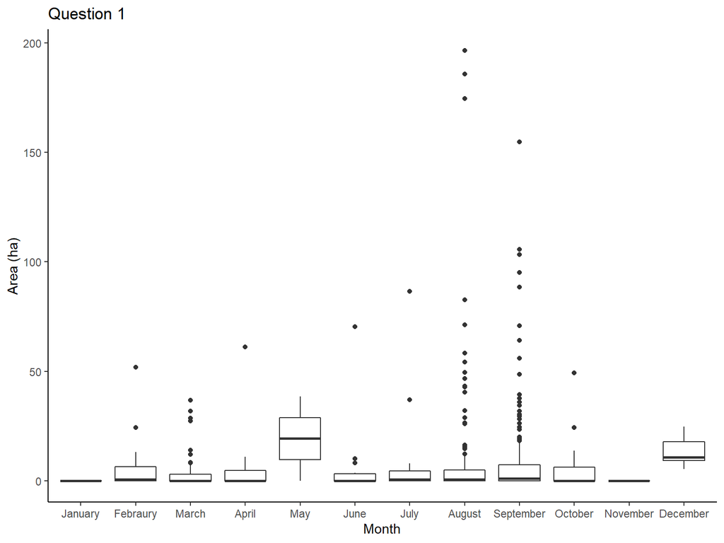

```r
#plotting
tibble_q1 %>%
  ggplot() +
  aes(x = fct_relevel(month, #reorder graph
                      "January",
                      "Febraury",
                      "March",
                      "April",
                      "May",
                      "June",
                      "July",
                      "August",
                      "September",
                      "October",
                      "November",
                      "December"),
      y = area) +
  geom_boxplot() +
  labs(x = "Month",
       y = "Area (ha)",
       title = "Question 1") -> plot_q1

plot_q1
```

### Answer

$R^2 = 0.0054$, which means that 99.5% of variation is unexplained, indicating that this is a weak model. The RMSE is 63.42 and the values range from 0.00 to 1090.84. This is further evidence that the model is weak as the data also skews toward 0 and there are a lot of outliers.

## Question 2

#### What `day` of the week has the largest forest fires?

### Methods

```r
#data wrangling
forest_fires %>%
  filter(area != 0) %>% #exclude areas that equal 0, wanted fires w/ actual area value to measure/summarize
  group_by(day) %>%
  summarize(mean_area = mean(area)) %>%
  #pivot to set up rename()
  pivot_wider(names_from = day,
              values_from = mean_area) %>%
  #rename days of the week
  rename("Friday" = fri,
         "Monday" = mon,
         "Saturday" = sat,
         "Sunday" = sun,
         "Thursday" = thu,
         "Tuesday" = tue,
         "Wednesday" = wed) %>%
  #pivot back to set up for plotting
  pivot_longer(Friday:Wednesday,
               names_to = "day",
               values_to = "mean_area") -> q2_tibble
q2_tibble
```

```
## # A tibble: 7 x 2
##   day       mean_area
##   <chr>         <dbl>
## 1 Friday         10.4
## 2 Monday         18.1
## 3 Saturday       51.1
## 4 Sunday         20.4
## 5 Thursday       32.2
## 6 Tuesday        22.4
## 7 Wednesday      18.1
```

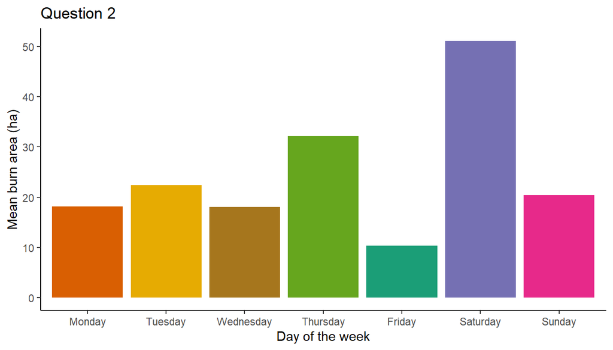

```r
#plotting
q2_tibble %>%
  ggplot() +
  aes(x = fct_relevel(day, #ordered by sequential order
                           "Monday", "Tuesday", "Wednesday",
                           "Thursday", "Friday", "Saturday", "Sunday"),
      y = mean_area,
      fill = day) +
  geom_col() +
  scale_fill_brewer(palette = "Dark2") +
  labs(x = "Day of the week",
       y = "Mean burn area (ha)",
       title = "Question 2") +
  #removes legend
  theme(legend.position = "none") -> plot_q2

plot_q2
```

### Answer

Saturday tends to have the largest forest fires.

## Question 3

#### What `season` has the most forest fires?

### Methods

```r
#data wrangling
forest_fires %>%
  #categorize months by season, new variable/column
  mutate(season = case_when(month %in% c("mar", "apr", "may") ~ "Spring",
                            month %in% c("jun", "jul", "aug") ~ "Summer",
                            month %in% c("sep", "oct", "nov")  ~ "Fall",
                            month %in% c ("dec", "jan", "feb") ~ "Winter")) %>%
  group_by(season) %>%
  count() -> tibble_q3 #count how many datapoints there are for each season

tibble_q3
```

```
## # A tibble: 4 x 2
## # Groups:   season [4]
##   season     n
##   <chr>  <int>
## 1 Fall     188
## 2 Spring    65
## 3 Summer   233
## 4 Winter    31
```

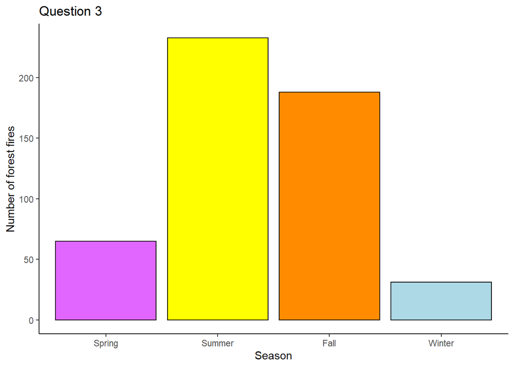

```r
#plotting
tibble_q3 %>%
  ggplot() +
  aes(x = fct_relevel(season,
                      "Spring", "Summer", "Fall", "Winter"),
      y = n,
      fill = season) +
  geom_col(color = "black") +
  scale_fill_manual(values = c("darkorange", #seasonal colors
                               "mediumorchid1",
                               "yellow",
                               "lightblue")) +
  labs(x = "Season",
       y = "Number of forest fires",
       title = "Question 3") +
  #removes legend
  theme(legend.position = "none") -> plot_q3

plot_q3
```

### Answer

Summer tends to have the most forest fires.

## Question 4

#### Do hotter days tend to be more humid?

### Methods

```r
#data wrangling
forest_fires %>%
  #categorize temp as High or Low depending on if the value is above or below the mean
  mutate(temp_threshold = ifelse(temp >= mean(temp),
                                 "High",
                                 "Low")) %>%
  select(RH, temp_threshold) -> tibble_q4 #nicer tibble output

tibble_q4
```

```
## # A tibble: 517 x 2
##       RH temp_threshold
##    <dbl> <chr>
##  1    51 Low
##  2    33 Low
##  3    33 Low
##  4    97 Low
##  5    99 Low
##  6    29 High
##  7    27 High
##  8    86 Low
##  9    63 Low
## 10    40 High
## # ... with 507 more rows
```

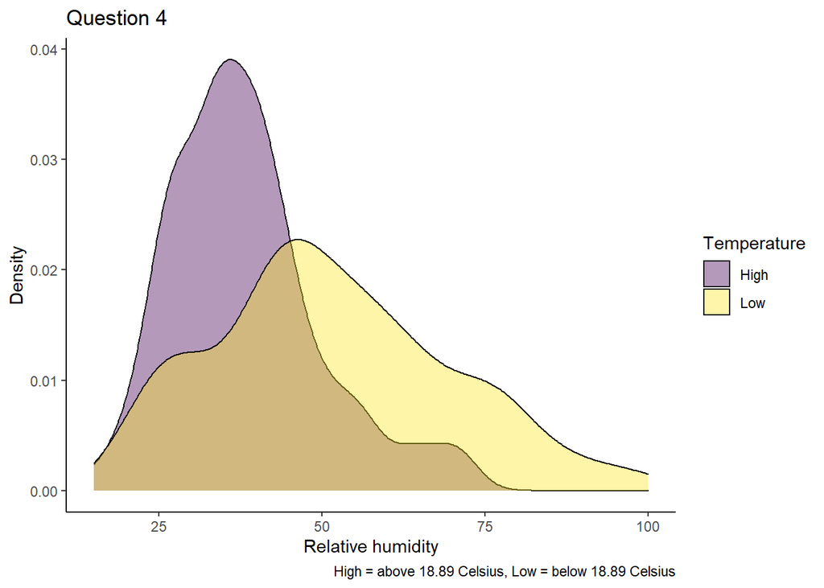

```r
#plotting
tibble_q4 %>%
  ggplot() +
  aes(x = RH,
      fill = temp_threshold) +
  geom_density(alpha = 0.4) +
  scale_fill_viridis_d(option = "viridis") +
  labs(x = "Relative humidity",
       y = "Density",
       title = "Question 4",
       fill = "Temperature",
       caption = "High = above 18.89 Celsius, Low = below 18.89 Celsius") -> plot_q4

plot_q4
```

### Answer

Days with a high temperature tend to have a lower humidity than days with a low temperature. Although it should be noted that the larger spread for low temperature days may be causing the mean to shift to the right.